# Size: L1 vs L2

## Data analysis

```
Source: local data frame [4 x 3]
Groups: Lang [?]

    Lang   List n_distinct(Subject)
  (fctr) (fctr)               (int)
1     L2      0                  47
2     L2      1                  53
3     L1      0                  18
4     L1      1                  16
```

```
Source: local data frame [4 x 3]
Groups: Lang [?]

    Lang   List n_distinct(Subject)
  (fctr) (fctr)               (int)
1     L2      0                  47
2     L2      1                  53
3     L1      0                  18
4     L1      1                  16
```

## Model Building

See the Orientation L1 vs L2 case for a description of the setup.

Our starting model is: `lmer(log(Time) ~ Type + List + Lang + (1 | List:Subject) + (1 | List:Type:Trial), data = DLM)`

```r
lmm<- lmer(log(Time) ~ Type + Lang + List + (1 | List:Subject)+ (1 | List:Type:Trial), data = DLM, REML=FALSE)
```

### Likelihood ratio

We gain a preliminary insight using likelihood ratio tests for main fixed effects:

```r
lmm.0 <- lmer(log(Time) ~ (1 | List:Subject)+ (1 | List:Type:Trial), data = DLM)
lmm.1 <- update(lmm.0, .~. + Type)
anova(lmm.0,lmm.1)
```

```
Data: DLM
Models:
lmm.0: log(Time) ~ (1 | List:Subject) + (1 | List:Type:Trial)
lmm.1: log(Time) ~ (1 | List:Subject) + (1 | List:Type:Trial) + Type
      Df  AIC  BIC logLik deviance Chisq Chi Df Pr(>Chisq)
lmm.0  4 1789 1810   -890     1781
lmm.1  5 1786 1813   -888     1776  4.34      1      0.037 *
---
Signif. codes:  0 '***' 0.001 '**' 0.01 '*' 0.05 '.' 0.1 ' ' 1
```

```r
lmm.2 <- update(lmm.0, .~. + Lang)
anova(lmm.1,lmm.2)
```

```
Data: DLM
Models:
lmm.1: log(Time) ~ (1 | List:Subject) + (1 | List:Type:Trial) + Type
lmm.2: log(Time) ~ (1 | List:Subject) + (1 | List:Type:Trial) + Lang
      Df  AIC  BIC logLik deviance Chisq Chi Df Pr(>Chisq)
lmm.1  5 1786 1813   -888     1776
lmm.2  5 1770 1797   -880     1760  15.9      0     <2e-16 ***
---
Signif. codes:  0 '***' 0.001 '**' 0.01 '*' 0.05 '.' 0.1 ' ' 1
```

```r
lmm.3 <- update(lmm, .~. + List)
anova(lmm.2,lmm.3)
```

```
Data: DLM
Models:
lmm.2: log(Time) ~ (1 | List:Subject) + (1 | List:Type:Trial) + Lang
lmm.3: log(Time) ~ Type + Lang + List + (1 | List:Subject) + (1 | List:Type:Trial)
      Df  AIC  BIC logLik deviance Chisq Chi Df Pr(>Chisq)
lmm.2  5 1770 1797   -880     1760
lmm.3  7 1769 1807   -877     1755  5.68      2      0.058 .
---
Signif. codes:  0 '***' 0.001 '**' 0.01 '*' 0.05 '.' 0.1 ' ' 1
```

We see that `Type` and `Lang` are significant. We use exhaustive search to find out which second order term to include.

### Exhaustive search

```r
lmm.6<-lmer(log(Time) ~ (Type + List + Lang)^2 + (1 | List:Subject) + (1 | List:Type:Trial),
          data=DLM, na.action="na.fail", REML=FALSE)

library(MuMIn)
dredge.res<-dredge(lmm.6, beta = c("none"), evaluate = TRUE, rank = "AICc", fixed = NULL, m.lim = NULL,  trace = FALSE)
print(dredge.res[1:5,])
```

```
Global model call: lmer(formula = log(Time) ~ (Type + List + Lang)^2 + (1 | List:Subject) +
    (1 | List:Type:Trial), data = DLM, REML = FALSE, na.action = "na.fail")
---
Model selection table
   (Int) Lng Lst Typ Lng:Typ Lst:Typ df logLik AICc delta weight
6   6.93   +       +                  6   -878 1768  0.00  0.310
8   6.88   +   +   +                  7   -877 1769  0.73  0.215
40  6.84   +   +   +               +  8   -876 1769  0.87  0.201
22  6.93   +       +       +          7   -878 1769  1.30  0.162
24  6.89   +   +   +       +          8   -877 1770  2.03  0.112
Models ranked by AICc(x)
Random terms (all models):
'1 | List:Subject', '1 | List:Type:Trial'
```

```r
attr(dredge.res, "model.calls")[1]
```

```
$`6`
lmer(formula = log(Time) ~ Lang + Type + (1 | List:Subject) +
    (1 | List:Type:Trial), data = DLM, REML = FALSE, na.action = "na.fail")
```

Or in a pretty table form:

(Intercept)

Lang

List

Type

Lang:List

Lang:Type

List:Type

df

logLik

AICc

delta

weight

6

6.93

6

-878.0

1768.1

0.0

0.31

8

6.88

7

-877.4

1768.8

0.7

0.21

40

6.85

8

-876.4

1768.9

0.9

0.20

22

6.93

7

-877.6

1769.4

1.3

0.16

24

6.89

8

-877.0

1770.1

2.0

0.11

The final model on which we base our exhaustive search is:

```r
require(lmerTest)
lmm <- lmer(formula = log(Time) ~ Lang + Type + (1 | List:Subject) +
    (1 | List:Type:Trial), data = DLM, REML = FALSE)
```

See below, in the Anova section, the summary of this model.

## Diagnostic plots

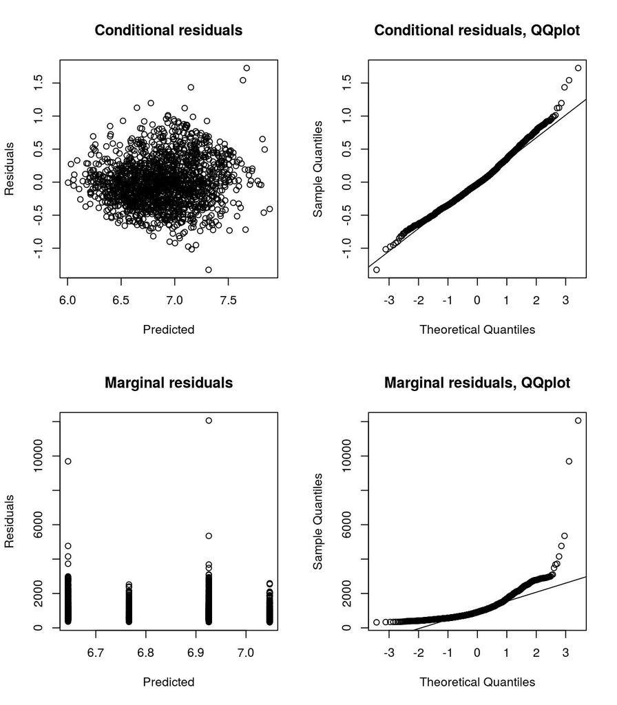

```r
#lmm<- glmer(Time ~ Lang + Type + (1 | Subject)+ (1 | Type:List:Type:Trial), data = DLM,family=Gamma(link = "identity"))
par(mfrow=c(2,2))
# plot(lm4,which=1:4)

plot(fitted(lmm, Type = "response"), residuals(lmm, Type = "response"),
     main = "Conditional residuals", xlab = "Predicted", ylab = "Residuals")

res <- residuals(lmm, Type = "response")
qqnorm(res, main = "Conditional residuals, QQplot")
qqline(res)

lm.0 <- lm(log(Time) ~ Type + Lang, data = DLM)
x <- model.matrix(lm.0)
pred <- x %*% fixef(lmm)
res <- DLM$Time - pred
plot(pred, res, main = "Marginal residuals", xlab = "Predicted", ylab = "Residuals")
qqnorm(res, main = "Marginal residuals, QQplot")
qqline(res)
```

The joint qqplot looks normal. The marginal looks less nice.

## p-values

Anova of type III with Satterwhite Approximation:

```r
require(lmerTest)
anova(lmm)
```

```
Analysis of Variance Table of type III  with  Satterthwaite
approximation for degrees of freedom
     Sum Sq Mean Sq NumDF DenDF F.value  Pr(>F)
Lang  3.053   3.053     1 129.7   21.90 7.1e-06 ***
Type  0.658   0.658     1  31.6    4.72   0.037 *
---
Signif. codes:  0 '***' 0.001 '**' 0.01 '*' 0.05 '.' 0.1 ' ' 1
```

and the effects with t test:

```r
summary(lmm)
```

```
Linear mixed model fit by maximum likelihood t-tests use Satterthwaite approximations to degrees
  of freedom [lmerMod]
Formula: log(Time) ~ Lang + Type + (1 | List:Subject) + (1 | List:Type:Trial)
   Data: DLM

     AIC      BIC   logLik deviance df.resid
    1768     1800     -878     1756     1623

Scaled residuals:
   Min     1Q Median     3Q    Max
-3.554 -0.662 -0.079  0.579  4.625

Random effects:
 Groups          Name        Variance Std.Dev.
 List:Subject    (Intercept) 0.0802   0.283
 List:Type:Trial (Intercept) 0.0221   0.149
 Residual                    0.1394   0.373
Number of obs: 1629, groups:  List:Subject, 134; List:Type:Trial, 32

Fixed effects:
             Estimate Std. Error       df t value Pr(>|t|)
(Intercept)    6.9257     0.0488  67.4000  141.92  < 2e-16 ***
LangL1        -0.2811     0.0601 129.7000   -4.68  7.1e-06 ***
TypeMISMATCH   0.1216     0.0560  31.6000    2.17    0.037 *
---
Signif. codes:  0 '***' 0.001 '**' 0.01 '*' 0.05 '.' 0.1 ' ' 1

Correlation of Fixed Effects:
            (Intr) LangL1
LangL1      -0.317
TypMISMATCH -0.563 -0.003
```

Bootstrap confidence intervals

```r
#confint(lmm,method="Wald")
confint(lmm,method="boot")
```

```
                2.5 % 97.5 %
.sig01        0.24155  0.320
.sig02        0.10172  0.187
.sigma        0.35983  0.387
(Intercept)   6.82954  7.022
LangL1       -0.40269 -0.153
TypeMISMATCH  0.00841  0.230
```

We also include the analysis via `merTools` package that calculates simulated values of the (fixed and random) effects from the posterior using the function `arm::sim`:

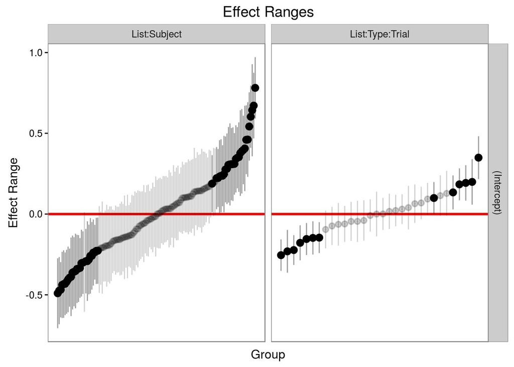

```r
detach("package:lmerTest",unload=TRUE)
require(merTools)
lmm <- lmer(formula = log(Time) ~ Lang + Type + (1 | List:Subject) +
    (1 | List:Type:Trial), data = DLM, REML = FALSE)
plotREsim(REsim(lmm, n.sims= 100), level=0.95, stat="mean")
```

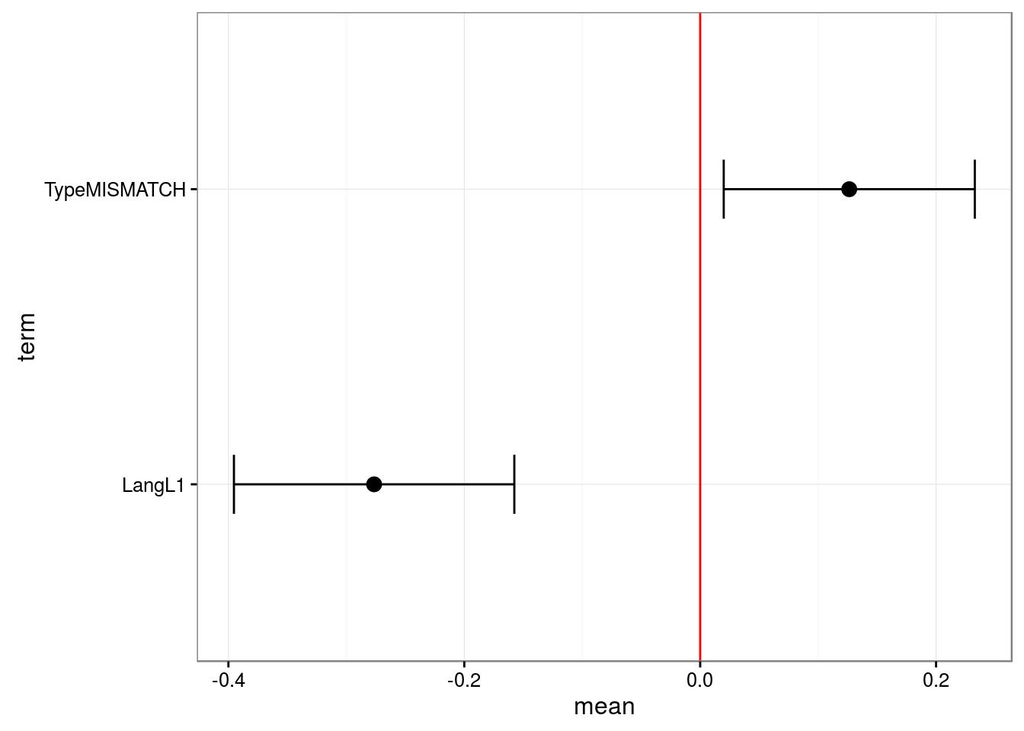

```r
plotFEsim(FEsim(lmm, n.sims = 100), level = 0.95, stat = 'mean', intercept = FALSE)
```

## Conclusions

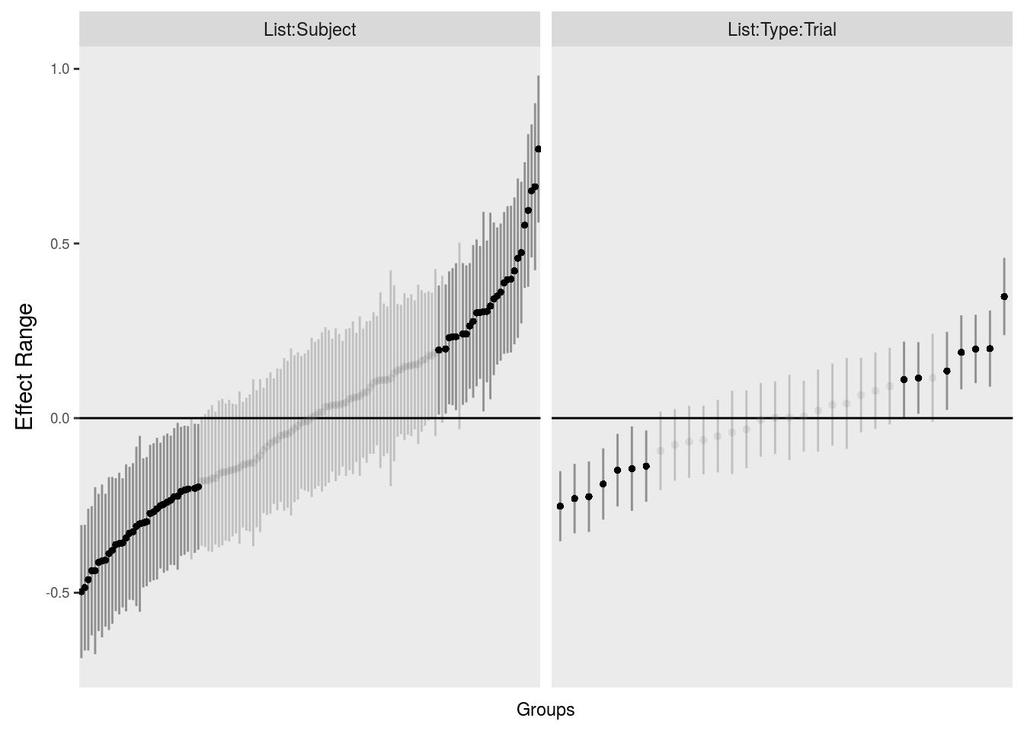

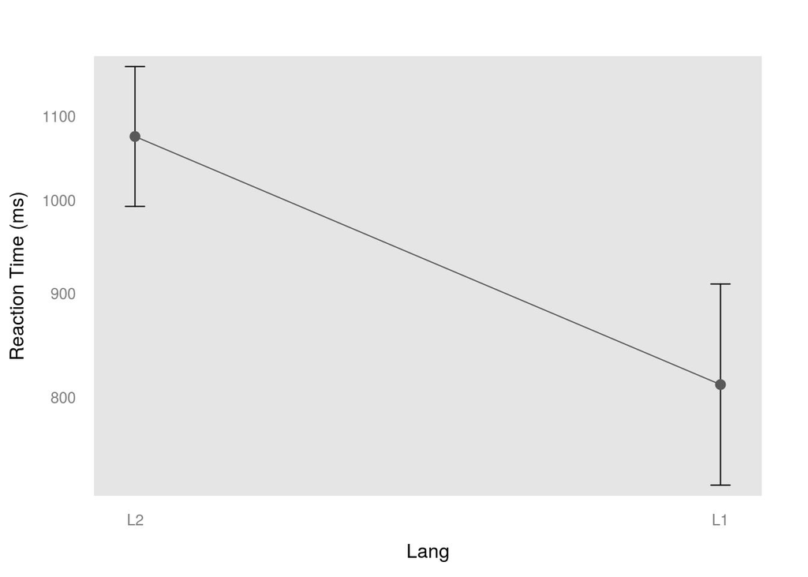

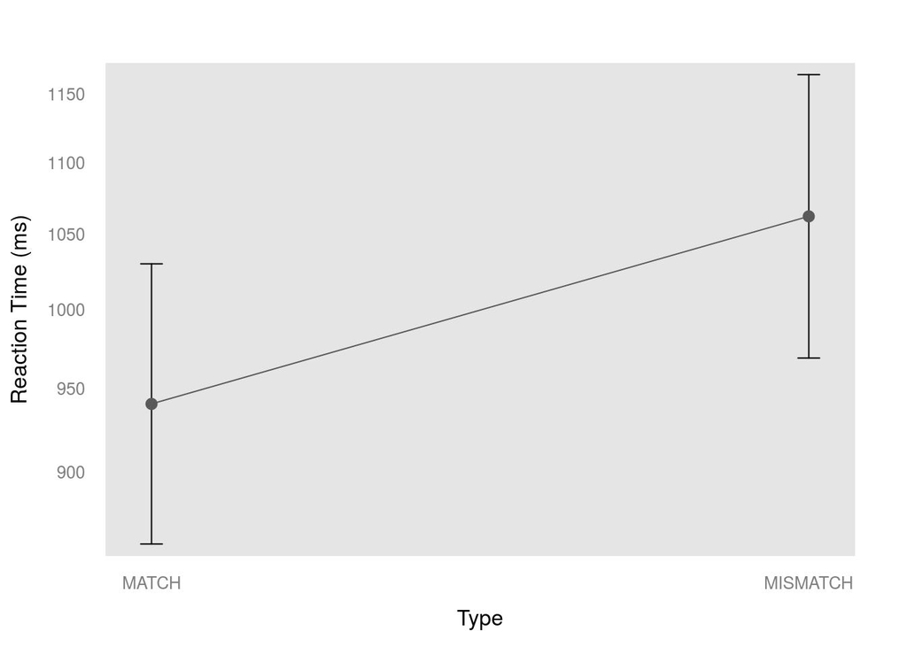